# In class practice & notes

# 8 Bond price when sell

## 8.1 Accrued interest

- Let $\omega$ be the remaining portions of coupon when sell. The accrued interest (應計利息) will be

The present value of the bonds when sell:

$$\begin{equation}
\begin{aligned}
PV &=clean \ price + AI = \frac{C}{(1+\frac{r}{m})^{\omega}}+...+\frac{C+F}{(1+\frac{r}{m})^{\omega+n-1}} \\
&= \frac{F}{(1+\frac{r}{m})^{\omega+n-1}}+\sum_{i=0}^{n-1} \frac{C}{(1+\frac{r}{m})^{\omega+i}} \\
\end{aligned}
\end{equation}$$
Example(TBD):

# 9 Bond price volatility

Volatility measures how bond price changes wrt change of the interest rate

The Macaulay duration (MD) is a weighted average of the times to an asset’s cash flows.

The weights are cash flow’s present value divided by the asset’s price.

$$\mathrm{MD}\triangleq \frac{1}{P} \sum_{i=1}^{n} \frac{C_{i}}{(1+y)^{i}} \cdot i$$

> 投資債券屬於固定收益的一種，主要的獲利來自於債券的配息，所以理應是非常穩定的投資標的。持有債券就好像是把錢借出去，然後靠著收取利息來獲利是一樣的，只要配息及本金可以拿回來，沒有不會獲利的道理。雖說債券依賴配息獲利，但是因為債券的到期時間較長，本金及配息很久以後才拿得回來，所以**債券的價值很容易就受到市場利率的變化而產生波動**。

> **債券的存續期間(Duration)，就是用來衡量市場利率的變化對債券價格的敏感度，一檔債券的存續期間愈長，就代表這檔債券對利率比較敏感，也就是只要市場利率稍有變化，就會造成債券價格較大的波動**。存續期間較短，當然對市場利率的敏感度就會比較低。

[存續期間：債券價格波動之指標-怪老子理財](https://www.masterhsiao.com.tw/CatBonds/Duration/Duration.php)

- Consider the sensitivity of the price of **level-coupon bond** wrt to the interest rate.
1. The price of the level-coupon bond is

$$P = \frac{C_{1}}{1+r} +\frac{C_{2}}{(1+r)^2}+\frac{C_{n}+F}{(1+r)^n}$$

2. The price change wrt return rate is

$$
$$\begin{equation}
\begin{aligned}
\frac{\mathrm{d}P }{\mathrm{d} (1+r)} &= \frac{\mathrm{d}\left [ C_{1}(1+r)^{-1}+...+(C_{n}+F)(1+r)^{-n} \right ] }{\mathrm{d} (1+r)} \\
&= -C_{1}(1+r)^{-2} + (-2)C_{2}(1+r)^{-3}+...+(-n)(C_{n}+F)(1+r)^{-n-1}
\end{aligned}
\end{equation}$$

3. The percentage change in $P$ and the percentage change in $1+r$ is

$$\begin{equation}
\begin{aligned}
\frac{\% \Delta \ in \ P}{\% \Delta \ in \ (1+r)} &= \frac{\frac{\mathrm{d}P }{P}}{\frac{\mathrm{d}(1+r) }{1+r}} \\
&= \frac{\mathrm{d} P}{\mathrm{d} (1+r)} \frac{1+r}{P}\\
&= \left [ -C_{1}(1+r)^{-1} + (-2)C_{2}(1+r)^{-2}+...+(-n)(C_{n}+F)(1+r)^{-n}\right ]/P
\end{aligned}
\end{equation}$$

3. Define MD of the level-coupon bond is

$$\mathrm{MD}\triangleq \frac{1}{P} \sum_{i=1}^{n} \frac{C_{i}}{(1+y)^{i}} \cdot i + \frac{nF}{(1+r)^{n}}$$

then we have

$$\frac{\% \Delta \ in \ P}{\% \Delta \ in \ (1+y)} = -\mathrm{MD}$$

### 9.0.1 Modified duration

> 雖然1+y的變化率對價格的變化率很重要，其實投資者更想知道殖利率的變化量(Δy)，對價格變化率(Δp/p)的敏感程度。也就是殖利率每上升1%時，債券價格會變化多少。

Since

$$\begin{equation}
\begin{aligned}
\frac{\% \Delta \ in \ P}{\% \Delta \ in \ (1+y)}
&= \frac{\mathrm{d} P}{\mathrm{d} (1+y)} \frac{1+y}{P}\\
&= -\mathrm{MD}
\end{aligned}
\end{equation}$$

thus we have

$$\begin{equation}
\begin{aligned}
\frac{\% \Delta \ in \ P}{ \Delta \ in \ (1+y)}
&= \frac{\mathrm{d} P}{\mathrm{d} (1+y)} \frac{1}{P}\\
&= -\frac{\mathrm{MD}}{1+y} \\
&\triangleq - \mathrm{Modified \ Duration}
\end{aligned}
\end{equation}$$

Note that if we measure in the annual interest rate, then we have

$$\frac{\mathrm{MD}}{1+\frac{YTM}{n}} = \mathrm{Modified \ Duration}$$

Thus, the percentage price change is equal to negative Modified Duration multiply the yield change.

$$\begin{equation}
\begin{aligned}
\% \Delta \ in \ P &= - \mathrm{Modified \ Duration} \cdot \Delta \ in \ (1+y) \\
\end{aligned}
\end{equation}$$

Example: Modified duration 11.54, change in yield 0.1%, the price should **decrease 1.154%**

### 9.0.2 Effective duration

$$\frac{P_{-}-P_{+}}{P_{0}(y_{+}-y_{-})}$$

## 9.1 Convexity

$$\mathrm{convexity} \triangleq \frac{\partial^{2}{P}}{\partial{y}^{2}} \frac{1}{P}$$

# 10 Immutization

> A portfolio is immunized when it is “unaffected” by interest rate changes.

[Bond Portfolio Management - NYU Stern](http://people.stern.nyu.edu/ashapiro/courses/B01.231103/FFL13.pdf)

# 11 Spot rate

Compare the different bonds to the present base. Change the coumpound rate in coupon bonds to sigle rate. Useful when you have investment profolio.

1. The i-period spot rate $S(i)$ is the yield to maturity of an i-period zero-coupon bond.
2. The PV of one dollar i-periods from now is by definition

$$\frac{1}{\left [ (1+S(i) \right ]^{i}}$$

which is the price of the i-period zero-coupon bond.

3. The **one-period spot rate** is called the **short rate**
4. Spot rate curve: Plot of spot rate vs. maturity: $S(1),S(2),...S(n)$

While there’s no zero-coupon bond in the market for long periods.

Spot rate for longer periods cannot be directly observed.

Consider a level-coupon bond:

$$P = \sum_{i=1}^{n} \frac{C}{\left [ 1+S(i) \right ]^{i}} + \frac{F}{\left [ 1+S(n) \right ]^{n}}$$

It discount each cash flow along the spot rate.

# 12 Forward rate

Consider 2 types of investment:

1. Invest 1 dollar to $j$ periods, get $\left [ 1+S(j) \right ]^{j}$ dollar at time $j$.
2. Invest 1 dollar in bonds for $i$ periods, at time $i$ invest proceeds in bonds for another $j-i$ periods, where $j>i$.

We will have $\left [ 1+S(i) \right ]^{i} \cdot \left [ 1+S(i,j) \right ]^{j-i}$ dollars at time $j$.

Define $S(i,j)$ to be the $(j-i)$ period spot rate $i$ periods from now, and called it forward rate $f(i,j)$.

Since the PV of these 2 kinds of investment should be equal, we have

$$\left [ 1+S(j) \right ]^{j} =\left [ 1+S(i) \right ]^{i} \cdot \left [ 1+S(i,j) \right ]^{j-i}$$

thus we have

$$S(i,j) =
\left \{ \frac{\left [ 1+S(j) \right ]^{j}}{\left [ 1+S(i) \right ]^{i}}\right \}^{\frac{1}{j-i}} -1 \triangleq f(i,j)$$

[如何用理論即期利率算出遠期利率-綠角財經筆記](http://greenhornfinancefootnote.blogspot.com/2010/08/how-to-compute-forward-rates-from.html)

# 13 Options

## 13.1 Definition

> 選擇權是一種契約，一種權利的交易。 顧名思義你有權利決定是否要履行契約，也可以選擇 " 買 " 這個權利或 " 賣 " 這個權利！ 買方，就是買進權利的角色；賣方，則是賣出權利的角色。

[figure not shown]

選擇權買賣方vs.買賣權

## 13.2 Types of options

European vs. American

歐式選擇權（European Option）則是指買方有權利、但無須負義務，而**只能在到期日當天**，以履約價格買進或賣出標的資產，亦即這種選擇權**不可提早執行**，迨至到期時雙方仍是以履約價格進行交割。大部分在店頭市場交易的選擇權係為歐式選擇權。

美式選擇權（American Option）係指買方有權利、但無須負義務，**在到期日之前或當天**，以履約價格買進或賣出標的資產，換言之，這種選擇權**可以被提早執行**，到期時雙方則是以履約價格進行交割。大部分在交易所掛牌的選擇權商品均為美式選擇權。

## 13.3 Payoff

### 13.3.1 Convinient convetions

- C: call value (買權權利金)
- P:put value (賣權權利金)
- X/K: strike price (履約價)
- S: stock price (標的物現貨價格)
- D: dividends (是否有發股利)

### 13.3.2 Mathematic representation

- The payoff of a call at expriation is

$$C = \max (0,S-X)$$

When the **stock price is lower than the strike pirce** ($S<X$), the investor will give up call option.

- The payoff of a pu at expriation is

$$P = \max (0,X-S)$$

When the **stock price is higher than the strike pirce** ($S>X$), the investor will give up put option.

## 13.4 Strategy

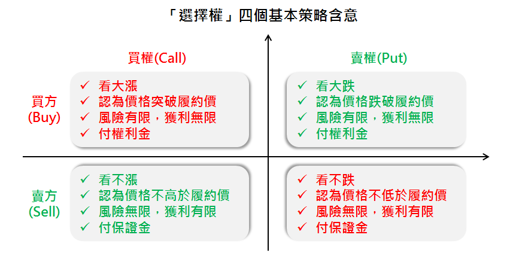

選擇權的四個象限-統一期貨

## 13.5 Terminology

| Option | Strike Price | Stock Price | Terminology |
| --- | --- | --- | --- |
| Call | 45 | 40 | **Out**-of-the-money(放棄) |
| Call | 40 | 40 | At-of-the-money |
| Call | 35 | 40 | **In**-of-the-money(賺錢) |
| Put | 80 | 100 | **Out**-of-the-money(放棄) |
| Put | 100 | 100 | At-of-the-money |
| Put | 130 | 100 | **In**-of-the-money(賺錢) |

## 13.6 Straddle vs. Strangle

> 現在談到的跨、勒式，則是 call 和 put同時交易。 買進 跨式/勒式，就是大漲你賺，大跌你也賺！ 賣出 跨式/勒式，就是不漲不跌最好，盤整我最賺！

波動率策略: 你預期市場未來是**大漲大跌** 或 **盤整**

1. 不去預測未來指數漲跌
2. 同時交易 call 和 put
3. 同時做 買進 或 賣出，例如買進跨式，就是同時買進call/put
4. 獲利的關鍵在 判斷未來市場的波動率是大是小

買進跨式部位 Long Straddle 大漲你賺，大跌你也賺！！！ 市場正好被某個 重大事件影響，但不清楚事情的演變會如何。

這時候你可以利用 買進跨式部位策略，只要出現 大漲或大跌 就可以獲利。

使用時機：

1. 重大事件醞釀加溫時
2. 重大政策宣布前日
3. 重大選舉前幾日
4. 連續假期開始前
5. 股市出現天量時
6. 預期會有大波段，但無法預期漲或跌

### 13.6.1 預期大漲或大跌

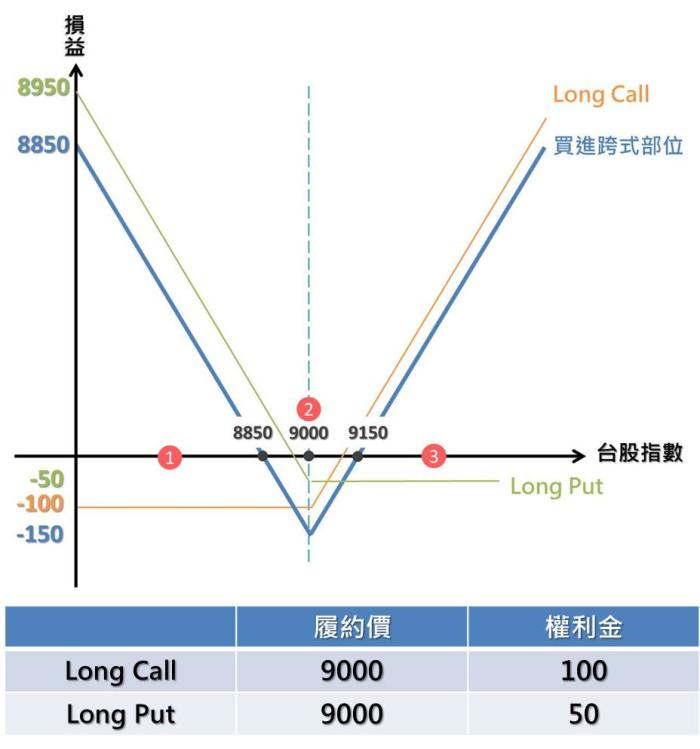

買進跨式部位 Long Straddle

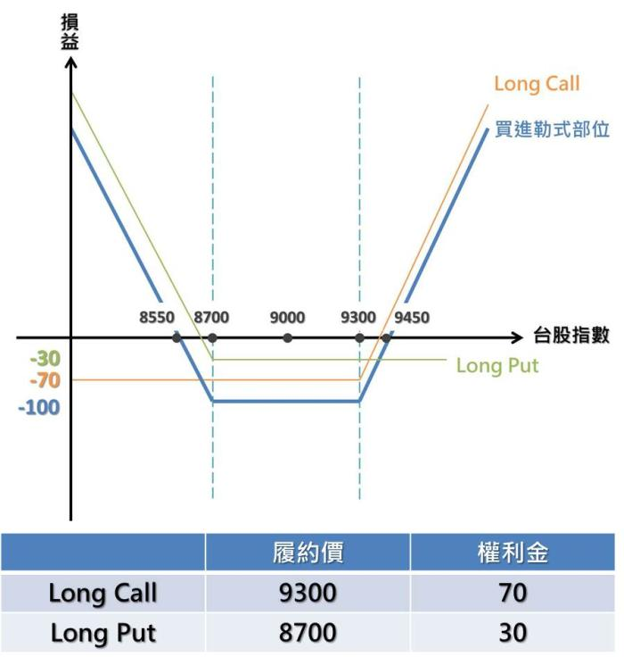

買進勒式部位 Long Strangle

### 13.6.2 預期波動不大

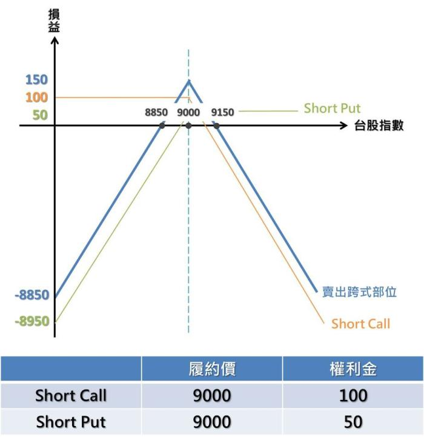

賣出跨式部位 Short Straddle

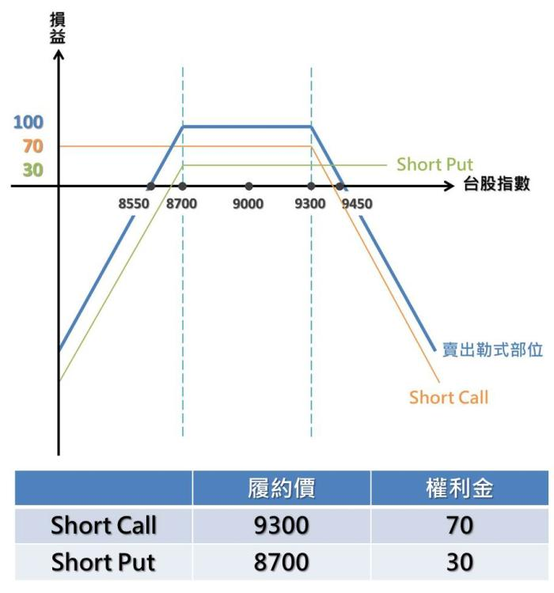

賣出勒式部位 Short Strangle

交易策略：

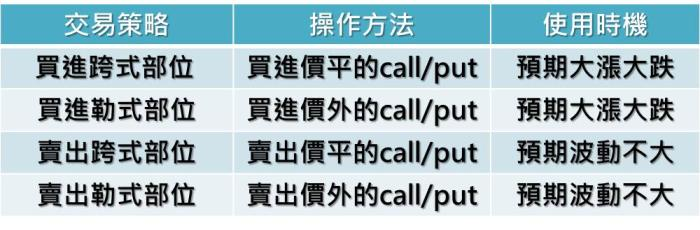

[選擇權的跨式與勒式-期權天空~日盛巧克力](https://js7eleven.pixnet.net/blog/post/239815222)

## 13.7 Option pricing model

## 13.8 Black-Scholes Model

Also called Black-Scholes-Merton Model

### 13.8.1 Basic assumptions

| Assumptions | Violation |
| --- | --- |
| 資本市場完美、沒有稅或交易成本、股票價格沒有上下限、任何五票可以無限分割、可無限賣空 | 景氣不好的時候政府可能會禁止賣空 |
| 股價取對數後符合常態分配 | 有可能會集中在某些區間 |
| 若令股價過程為常態分配，股價可能值將從負無窮大到正無窮大 | 真實股價沒有負值 |
| 無風險利率、股票報酬率的波動度為常數 | FED常更改無風險利率通常隨季度調整、波動不為常數 |
| 選擇權存續期間，股票不發放任何股利 |  |
| 歐式選擇權，只能在到期日時履約 | 還有美式選擇權 |
| 標的股票不會違約 | 有可能股票會下市 |
| 股價是連續的，不會有突發性股價跳空的情況發生 | 最近常跳空 |

### 13.8.2 Formula

$$\begin{equation}
\begin{aligned}
c &= S_{0}N(d_{1})-Ke^{-rT}N(d_{2}) \\
p &= Ke^{-rT}N(-d_{2})-S_{0}N(-d_{1}) \\
where \ \ d_{1} &= \frac{\ln(S_{0}/K)+(r+\sigma^{2}/2)T}{\sigma \sqrt(T)} \\
d_{2} &= \frac{\ln(S_{0}/K)+(r-\sigma^{2}/2)T}{\sigma \sqrt(T)} = \sigma \sqrt(T) \\
\end{aligned}
\end{equation}$$

- Concept: 現價($S_{0}$) 服從常態分佈，履約價($K$)要折現回來，服從常態分佈。$\sigma$為標的物波動率(估計)。$r$為無風險利率。

### 13.8.3 Put Call Parity

- 買賣權平價關係

$$\begin{equation}
\begin{aligned}
C+Xe^{-rT} &= P+S \\
where \ \ C &= call \ premium \\
Xe^{-rT} &= present \ value \ of \ the \ strike \\
P &= put \ premium \\
S &= the \ current \ price \ of \ the \ underline \\
\end{aligned}
\end{equation}$$

- Geometric Bronian Motion

$$\mathrm{d}S_{t} := \mu S_{t}\mathrm{d}d_{t} +\sigma S_{t} \mathrm{d}B_{t}, 0\leq t \leq T$$
where $S_{t}$ is the stock price at time $t$, $\mu$ is the drift rate(股價年收益率的期望值),$\sigma$ is the volatility of the price in years, $B_{t}$ is the Brownian motion. Notice that $\mu, \sigma$ are constants.

## 13.9 Option greek

| Greek | Measure | Affected by | Affects |
| --- | --- | --- | --- |
| Delta | Impact of underlying price move(per $1) | Time until expiration, volatility, gamma, price | Option Price |
| Gamma | Impact of underlying price move(per $1) | Time until expiration, volatility, price | Delta |
| Theta | Impact of passage of time(per day) | Time until expiration, price, volatility | Option Price |
| Vega | Impact of volatility change(per 1%) | Time until expiration, volatility | Option Price |
| Rho | Impact of interest rate change (per 1%) | Interest rate, time until expiration | Option Price |

# 14 Random walks

## 14.1 Simulation

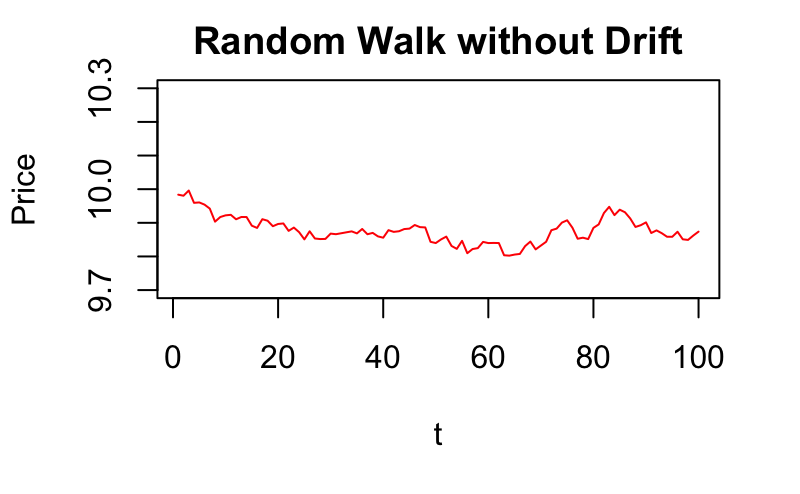

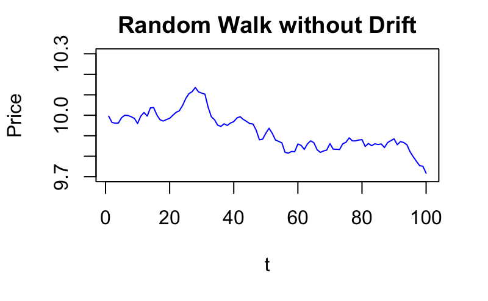

[Techincal Analysis with R](https://bookdown.org/kochiuyu/Technical-Analysis-with-R/simulation.html)

# 15 BOPM

## 15.1 Assumption

- **Time is discrete** and measure in periods.
- Stock is following a **discrete random walk**.
- If the current stock price is $S$, it can go to $Su$ with probability $q$ and $Sd$ with probability $1-q$, where $0<q<1$ and $u>d$.
- $u>R>d$ must hold to rule out arbitrage.

## 15.2 Notation

- R: gross return
- r: the continuously compounded riskless rate per period, from $R\triangleq e^{r}$
- S: stock price
- u: mutiplier whehn price goes up
- d: mutiplier whehn price goes down
- X: strike price
- n: numbers of periods to expiration

## 15.3 Payoff

Single period - call option

$$C_{u} = max(0,Su-X) \\
C_{d} = max(0,Sd-X)$$

## 15.4 Pricing

- Consider no-arbitrage opportunity market
- Invest $h$ shares of stock and $B$ dollars bond with risk-free return rate $R$.
- $h$ and $B$ are unknown.

We have

$$hSu+RB = C_{u} \\
hSd+RB = C_{d}$$

Solve the equation,

$$\begin{equation}
\begin{aligned}
h &= \frac{C_{u}-C_{d}}{Su-Sd} \geq 0 \\
B &= \frac{uC_{d}-dC_{u}}{(u-d)R} \\
\end{aligned}
\end{equation}$$

By no-arbitrage principle, the European call should cost the same as the equivalent portfolio.

$$C=hS+B$$

Substitute $h$ and $B$,

$$\begin{equation}
\begin{aligned}
hS+B &= (\frac{C_{u}-C_{d}}{Su-Sd})S+\frac{uC_{d}-dC_{u}}{(u-d)R} \\
&= \frac{(\frac{R-d}{u-d})C_{u}+(\frac{u-R}{u-d})C_{d}}{R}
\end{aligned}
\end{equation}$$

Notice that the option value is independent of $q$ now. The option value is hence independent of the expected value of the future stock $qSu+(1-q)Sd$. The option value depends on $u$,$d$(the size of price changes), the investor must agree with.

Pseudo probability
$$\begin{equation}
\begin{aligned}
hS+B &= \frac{(\frac{R-d}{u-d})C_{u}+(\frac{u-R}{u-d})C_{d}}{R} \\
&= \frac{pC_{u}+(1-p)C_{d}}{R} \\
p &\triangleq \frac{R-d}{u-d} \\
\end{aligned}
\end{equation}$$

By backward induction, for 2 periods we have

$$C_{u} = \frac{pC_{uu}+(1-p)C_{ud}}{R} \\
C_{d} = \frac{pC_{du}+(1-p)C_{dd}}{R}$$

where

$$\begin{equation}
\begin{aligned}
C &= \frac{pC_{u}+(1-p)C_{d}}{R} \\
&= \frac{p \frac{pC_{uu}+(1-p)C_{ud}}{R}+(1-p)\frac{pC_{du}+(1-p)C_{dd}}{R}}{R} \\
&=\frac{p^2C_{uu}+2p(1-p)C_{ud}+(1-p)^2C_{dd}}{R^2} \\
&=\frac{p^2 \max(0,Suu-X)+2p(1-p)\max(0,Sud-X)+(1-p)^2\max(0,Sdd-X)}{R^2}
\end{aligned}
\end{equation}$$

For n periods

$$C = \frac{\sum_{j=0}^{n}\binom{n}{j}p^{j}(1-p)^{n-j}\max(0,Su^{j}d^{n-j}-X)}{R^{n}} \\
P = \frac{\sum_{j=0}^{n}\binom{n}{j}p^{j}(1-p)^{n-j}\max(0,X-Su^{j}d^{n-j})}{R^{n}}$$

where

$$p_{j} \triangleq \frac{\binom{n}{j}p^{j}(1-p)^{n-j}}{R^{n}}$$

# 16 Risk Neutral Pricing Theory

## 16.1 Meaning

風險中性定價理論於資本市場中的意義

1. 市場不存在任何套利可能性的條件下，如果衍生證券的價格依然依賴於可交易多基礎證券，則 **衍生證券的價格是與投資者的風險態度無關的**
2. 在數學上表現為：研陞證券定價的微分方程中，並不包含有受投資者風險態度的變數，尤其是期望收益率
3. **風險中係病假與投資者的風險制度無關**，所有投資者都是風險中性的
4. 在風險中係的經濟環境中，**投資者並不要求任何的風險補償或風險報酬**，所以基礎證券與衍生證券的期望收益率都恰好等於無風險利率
5. 由於不存在任何的風險補償或風險報酬，市場的貼現玉也恰好等於無風險利率。**所以基礎證券或衍生證券的任何盈虧經無風險利率的貼現就是他們的現值**

[The valuation of options for alternative stochastic processes](https://www.sciencedirect.com/science/article/abs/pii/0304405X76900234)

## 16.2 Example

Recall BOPM, the one-period expected payoff on a call option is

$$\frac{pC_{u}+(1-p)C_{d}}{R}$$

the equation can be written as

$$C_{t} = \frac{1}{R_{f}} \hat{E} \left [ \tilde{C}_{t+1} \right ]$$

where $C_{t}$ is the call option at time $t$ and $\hat{E} \left [ \tilde{C}_{t+1} \right ]$ is the expected value of the call at time $t+1$ **in a risk-neutral world**. Therefore, $C_{t}$ is the “risk-neutral expected value” of $\tilde{C}_{t+1}$ dicsounted at the risk-free rate.

define

$$\frac{1}{R_{f}} = e^{-r}$$

where $r$ is defined as the continuously-compounded one-period interest rate.

## 16.3 Forward contract

1. A forward contract is an agreement where 2 parties agree to exchange an asset at some future date for a pre-agreed price.
2. The long(short) party agrees to receive(deliver) the asset in exchange for paying(receiving) this pre-agreed price at a price at a future date, date $T$.
3. No payment occurs between the partirs at the time of the agreement of the contract, only at the maturity of the contract.

The pay off to the long party at the maturity of the forward contract can be written as

$$\tilde{S}_{T} - K$$

where $\tilde{S}_{T}$ is the underlying asset price at the maturity of the forward contract. And $K$ is the previously agreed upon **delivery** price for the forward contract, which is said to equal the **forward price** at the agreement date fo the contract.

## 16.4 Portfolios

1. Assume that the underlying asset pays no dividends
2. Define $f$ as the current date $t$ value of the forward contract
3. $\tau \equiv T - t$ as its time until maturity
- At date $t$: Portfolio A: A long position in one forward contract writtern on an asset having current value of $S$ and haveing a forward price of $K$. Portfolio B: One share of the underlying asset plus borrowing an amount $e^{-r\tau}K$
- At date $T$: Portfolio A: $\tilde{S}_{T} - K$ Portfolio B: $\tilde{S}_{T} - K$

Since the 2 portfolio produce exactly the same cash flow at date $T$, the absence of arbitrage implies that their values at date $t$ must also be the same, that is

$$f = S-e^{-r\tau}K$$

Applying risk-neutral method, the current value of a long position is

$$f = e^{-r\tau} \hat{E} \left [ \tilde{S}_{T} - K \right ] = e^{-r\tau} \hat{E} \left [ \tilde{S}_{T}\right ]-e^{-r\tau} K$$

in the risk-neutral wourld,

$$\hat{E} \left [ \tilde{S}_{T}\right ] = Se^{r\tau}$$

thus

$$f = e^{-r\tau}Se^{r\tau} - e^{-r\tau}K = S-e^{-r\tau}K$$

which is the same as our earlier no-arbitrage derivation. Thus, the “risk-neutral” technique also works for forward contracts. Note when contract is agreed to initially, $f=0$ and $K=F$, where $F$ is the initial forward price.

we have

$$
$$\begin{equation}
\begin{aligned}
0 &= S-Fe^{-r\tau} \\
\Rightarrow F &=Se^{r\tau} \\
\end{aligned}
\end{equation}$$

## 16.5 Risk-adjusted of return

$$f = e^{-\theta\tau} \hat{E} \left [ \tilde{S}_{T}\right ]-e^{-r\tau} K$$

where $\theta$ is the **risk-adjested rate of return** on **risky asset**.

$\theta$ depends on risk aversion and might be the result of the **CAPM**(Capital Asset Pricing Model).

$$\theta =r+\beta(E\left [ \tilde{r}_{m} \right ]-r)$$

if $\theta$ is the true expected rate of return on the asset, then $E\left [ \tilde{S}_{T}\right ]=Se^{\theta\tau}$. We have

$$f = e^{-\theta \tau}Se^{\theta \tau} - e^{-r\tau}K = S-Ke^{-r\tau}$$

Notice that the result are the same as the case we presume

1. The expected rate if return on the asset is $r$
2. the discounted factor is $r$

while these 2 mistakes cancel out.

# 17 CAPM

CAPM 建立在馬科維茨(Markowitz)模型基礎上，馬科維茨模型的假設也包含在其中：

1. 投資者希望財富越多越好。效用是財富的函數，財富又是投資收益率的函數，因此可以認為效用為收益率的函數
2. 投資者能事先知道投資收益率的概率分佈為正態分佈
3. 投資風險用投資收益率的方差或標準差表示
4. 影響投資決策的主要因素為期望收益率和風險兩項
5. 投資者都遵守主宰原則(Dominance rule)，即同一風險水平下，選擇收益率較高的證券；同一收益率水平下，選擇風險較低的證券。以在無風險折現率R的水平下無限制地介入或貸出資金。

CAPM 的附加假設條件：

1. 可以在無風險折現率R的水平下無限制地借入或貸出資金
2. 所有投資者對證券收益率概率分佈的看法一致
3. 所有投資者具有相同的投資期限，而且只有一期
4. 所有證券投資可以無限制的細分，在任一投資組合裡可以含有非整數股份
5. 買賣證券沒有稅負及交易成本
6. 所有投資者可以即時免費獲得充分的市場信息
7. 不存在通貨膨脹，且折現率不變
8. 投資者具有相同預期，及他們對預期收益率、標準差和證券之間的共變異數具有相同的預期值

$$\theta =r+\beta(E\left [ \tilde{r}_{m} \right ]-r)$$

1. $r$ 是無風險收益率。筆記典型的無風險回報率是10年期的美國政府債券
2. 如果股票投資者需要承受額外的風險，那麼他講需要再無風險回報率的基礎上多獲得相應的溢價
3. 股票市場溢價(equity market premium) 就等於市場期望回報率減去無風險回報率($E\left [ \tilde{r}_{m} \right ]-r$)。證券風險溢價就是股票市場溢價和$\beta$系數的乘積($\beta(E\left [ \tilde{r}_{m} \right ]-r)$)

# 18 Risk-neutral derivation fo the BS formula

Condiser an European call option on a non-dividend paying stock. Apply risk-neutral technique

$$c = e^{-r\tau} \hat{E}\left [\mathrm{max}(0,\tilde{S}_{T}-X) \right ]$$

To evalurate the risk-neutral expectation, we need to make assupmtion regarding the probability distribution of $\tilde{S}_{T}$.

E.g. assume the stock price follows the BOPM, we will have Cox, Ross, Rubinstein binomial option formula.

Assume lognormal distribution for $\tilde{S}_{T}$

Define

$\mu$ to be annual expected rate of return of the stock

$\sigma^{2}$ to be annualized variance of the rate of return of the stock

If $\tilde{S}_{T}$ is a lognormally distributeed random variablem then we have

$$\mathrm{ln}(\tilde{S}_{T})\sim n(\mathrm{ln}(S)+(\mu-\sigma^{2}/2)\tau,\sigma^{2}\tau)$$

where $n(\cdot)$ is the normal probability density function.

The lognormal distribution is attractive because it alllows $\tilde{S}_{T}$ to take any value over $0$ to $\infty$. Continuoisly compounded returns on the stock over unit time internvals, $\mathrm{ln}(\tilde{S}_{t+1})-\mathrm{ln}(\tilde{S}_{t}) = \mathrm{ln}(\tilde{S}_{t+1}/\tilde{S}_{t})$ are normally distributed.

Calculate $\hat{E}\left [\mathrm{max}(0,\tilde{S}_{T}-X) \right ]$, if investor are risk-neutral then $\mu=r$.

$$\mathrm{ln}(\tilde{S}_{T})\sim n(\mathrm{ln}(S)+(r-\sigma^{2}/2)\tau,\sigma^{2}\tau)$$

$$
$$\begin{equation}
\begin{aligned}
c &= e^{-r\tau} \hat{E}\left [\mathrm{max}(0,\tilde{S}_{T}-X) \right ] \\
&= \int_{X}^{\infty}(S_{T}-X)g(S_{T})\mathrm{d}S_{T}
\end{aligned}
\end{equation}$$

Evaluating the integral, we have Black-Scholes formula

$$c = SN(d_{1}) - Xe^{-r\tau}N(d_{2})$$

where $N(\cdot)$ is normal distribution function and

$$
$$\begin{equation}
\begin{aligned}
d_{1} &= \frac{\mathrm{ln}(S/X)+(r+\sigma^{2}/2)\tau}{\sigma \sqrt{\tau}} \\
d_{2} &= d_{1} - \sigma \sqrt{\tau}
\end{aligned}
\end{equation}$$

where $r$ is usually taken as the risk-free interest rate on an investment maturaing in $\tau$ periods, at the expiration of the option contract. $\sigma$ can be estimated using historical data on stock prices or stock returns.

Denote $u_{i}$ as the continuously compounded stock return over the $i^{th}$ interval.

$$
$$\begin{equation}
\begin{aligned}
u_{i} \equiv \mathrm{ln}(\tilde{S}_{i}/\tilde{S}_{i-1}) \sim n((\mu-\sigma^{2}/2)\tau,\sigma^{2}\tau)
\end{aligned}
\end{equation}$$

$$
$$\begin{equation}
\begin{aligned}
\bar{u} &= \frac{1}{n}\sum_{i=1}^{n}u_{i} \\
\hat{s}^{2} &= \frac{1}{n-1}\sum_{i=1}^{n}(u_{i}-\bar{u})^{2} \\
\end{aligned}
\end{equation}$$

where
$$\sigma = \frac{\hat{s}}{\sqrt{\tau}}$$

Consider a European option on a dividend paying stock. The current value of the stock $S$ equals to the present value of the (assumed) riskless dividends paid during the life of the option $D$.

$$S= D +\tilde{S}$$